# R Notebook

## Data cleaning

### Unique

```r
n_distinct(daily_activity$Id)
```

```
[1] 33
```

```r
n_distinct(sleep$Id)
```

```
[1] 24
```

```r
n_distinct(weight$Id)
```

```
[1] 8
```

```r
n_distinct(hourly_calories$Id)
```

```
[1] 33
```

```r
n_distinct(hourly_intensities$Id)
```

```
[1] 33
```

We can see that we only have weight on 8 different people. So, this dataset will not give much insights.

### Duplicates

```r
print(paste("Activity:", sum(duplicated(daily_activity))))
print(paste("Sleep: ", sum(duplicated(sleep))))
print(paste("Calories: ", sum(duplicated(hourly_calories))))
print(paste("Intensities: ", sum(duplicated(hourly_intensities))))
```

[output not shown]

```r
sleep <- sleep %>%
  distinct() %>%
  drop_na()
```

### Date and time format

Now we will create a column for date and time to be able to merge and plot on the next parts.

```r
# intensities
hourly_intensities$ActivityHour = as.POSIXct(hourly_intensities$ActivityHour, format="%m/%d/%Y %I:%M:%S %p", tz=Sys.timezone())
hourly_intensities$time <- format(hourly_intensities$ActivityHour, format = "%H:%M:%S")
hourly_intensities$date <- format(hourly_intensities$ActivityHour, format = "%m/%d/%y")

# calories
hourly_calories$ActivityHour=as.POSIXct(hourly_calories$ActivityHour, format="%m/%d/%Y %I:%M:%S %p", tz=Sys.timezone())
hourly_calories$time <- format(hourly_calories$ActivityHour, format = "%H:%M:%S")
hourly_calories$date <- format(hourly_calories$ActivityHour, format = "%m/%d/%y")

# activity
daily_activity$ActivityDate=as.POSIXct(daily_activity$ActivityDate, format="%m/%d/%Y", tz=Sys.timezone())
daily_activity$date <- format(daily_activity$ActivityDate, format = "%m/%d/%Y")

# sleep
sleep$SleepDay=as.POSIXct(sleep$SleepDay, format="%m/%d/%Y", tz=Sys.timezone())
sleep$date <- format(sleep$SleepDay, format = "%m/%d/%Y")
```

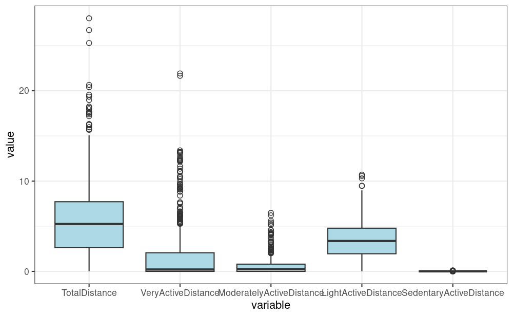

```r
daily_activity_long <- melt(
  select(daily_activity, Id, ActivityDate, TotalDistance, VeryActiveDistance, ModeratelyActiveDistance, LightActiveDistance, SedentaryActiveDistance),
  id = c("Id", "ActivityDate")
)

daily_activity_long %>%
  ggplot(aes(x= variable, y = value)) +
  geom_boxplot(fill = "lightblue",
               outlier.shape = 1,
               outlier.size = 2) +
  theme_bw()
```

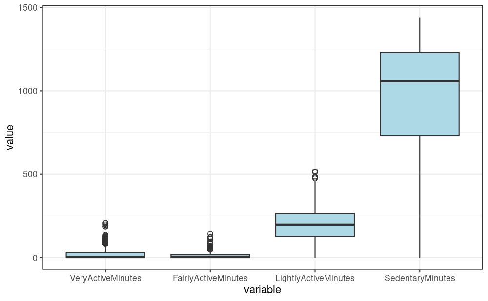

```r
daily_activity_long <- melt(
  select(daily_activity, Id, ActivityDate, VeryActiveMinutes, FairlyActiveMinutes, LightlyActiveMinutes, SedentaryMinutes),
  id = c("Id", "ActivityDate")
)

daily_activity_long %>%
  ggplot(aes(x= variable, y = value)) +
  geom_boxplot(fill = "lightblue",
               outlier.shape = 1,
               outlier.size = 2) +
  theme_bw()
```

## Plots

### Activity

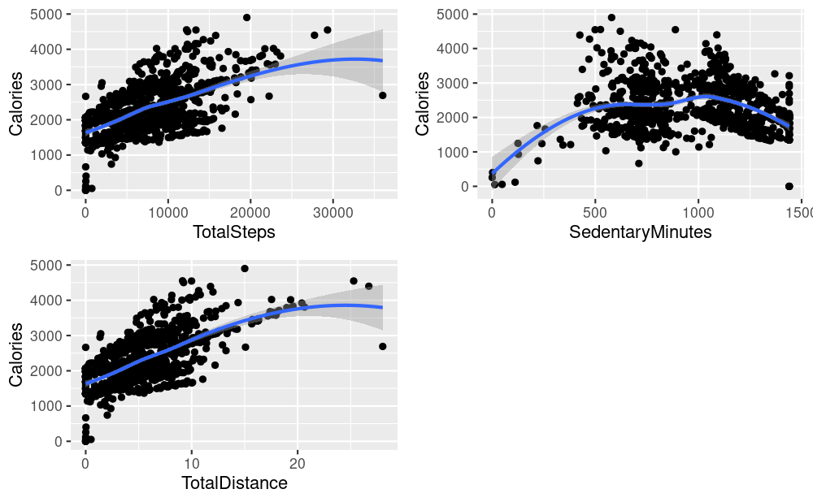

```r
ggarrange(
  ggplot(daily_activity, mapping = aes(x = TotalSteps, y = Calories)) + geom_point() + geom_smooth(),
  ggplot(daily_activity, mapping = aes(x = SedentaryMinutes, y = Calories)) + geom_point() + geom_smooth(),
  ggplot(daily_activity, mapping = aes(x = TotalDistance, y = Calories)) + geom_point() + geom_smooth()

)
```

We can clearly conclude that more steps and more distance equals more calories burned.

### Intensity and calories

Lets find how intensity and calories vary though the day and how they are corelated.

```r
intensities_calories <- merge(hourly_intensities, hourly_calories, by = c("Id", "ActivityHour", "date", "time"))

hourly_means <- intensities_calories %>%
  group_by(time) %>%
  summarize(mean_calories = mean(Calories),
            mean_intensity = mean(TotalIntensity))

hourly_means
```

[output not shown]

```r
ggarrange(
  hourly_means %>%
    ggplot(aes(x = time)) +
    geom_point(aes(y = mean_calories), size = 1.5) +
    scale_y_continuous(breaks = seq(0, 150, 50)) +
    coord_cartesian(ylim = c(0, 150)) +
    theme(axis.text.x = element_text(angle = 90)) +
    labs(x = "Hour of Day", y = "Calories", color = "Metric", title = "Average Calories Over Time"),

  hourly_means %>%
    ggplot(aes(x = time)) +
    geom_point(aes(y = mean_intensity * 100), size = 1.5) +
    theme(axis.text.x = element_text(angle = 90)) +
    labs(x = "Hour of Day", y = "Intensity", color = "Metric", title = "Average Intensity Over Time"),


  intensities_calories %>%
    ggplot(aes(x = Calories, y = TotalIntensity)) +
    geom_jitter() +
    geom_smooth()
)
```

[output not shown]

### Sleep

```r
sleep <- sleep %>%
  mutate(TotalTimeNotAsleep = TotalTimeInBed - TotalMinutesAsleep)
```

```r
# Create a histogram of total minutes asleep
ggplot(sleep, aes(x = TotalMinutesAsleep)) +
  geom_histogram(binwidth = 45, fill = "skyblue", color = "black") +
  labs(x = "Total Minutes Asleep", y = "Frequency", title = "Distribution of Total Minutes Asleep") +
  theme_bw()
```

[output not shown]

```r
ggplot(sleep, aes(x = TotalMinutesAsleep, y = TotalTimeInBed)) +
  geom_point(color = "skyblue") +
  labs(x = "Total Minutes Asleep", y = "Time in bed", title = "Total Minutes Asleep vs. Total Time in Bed") +
  theme_bw()
```

[output not shown]

```r
# Calculate average sleep duration per night
average_sleep <- sleep %>%
  group_by(Id) %>%
  summarize(AverageMinutesAsleep = mean(TotalMinutesAsleep))

# Create a bar plot of average sleep duration per night
ggplot(average_sleep, aes(x = factor(Id), y = AverageMinutesAsleep)) +
  geom_rect(xmin = -Inf, xmax = Inf, ymin = 420, ymax = 540, fill = "lightblue", alpha = 0.1) +  # Adds areaof de 7 hours - 9 hours
  geom_bar(stat = "identity", fill = "skyblue") +
  theme_bw() +
  labs(x = "ID", y = "Average Minutes Asleep", title = "Average Sleep Duration per Night") +
  theme(axis.text.x = element_text(angle = 90, vjust = 0.5, hjust=1))
```

[output not shown]

### Weight

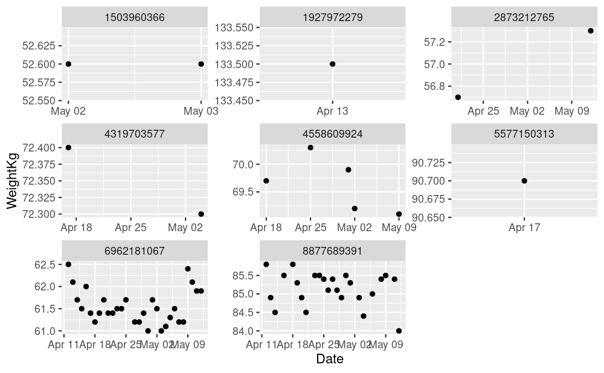

```r
# Convert the date variable to a Date object
weight$Date <- as.Date(weight$Date, format = "%m/%d/%Y %H:%M:%S")

ggplot(weight, aes(x = Date, y = WeightKg)) +
  geom_point() +
  facet_wrap(~ Id, scales = "free")
```

```r
  labs(x = "Date", y = "Weight (Kg)", title = "Weight Trend Over Time")
```

```
$x
[1] "Date"

$y
[1] "Weight (Kg)"

$title
[1] "Weight Trend Over Time"

attr(,"class")
[1] "labels"
```

### Combined

We want to understand better if sleep has any impact in activity on the day

```r
average_activity <- daily_activity %>%
  group_by(Id) %>%
  summarize(AverageTotalSteps = mean(TotalSteps),
            AverageTotalDistance = mean(TotalDistance),
            AverageCalories = mean(Calories))


combined_data = merge(sleep, daily_activity, by = c("Id", "date"))
```

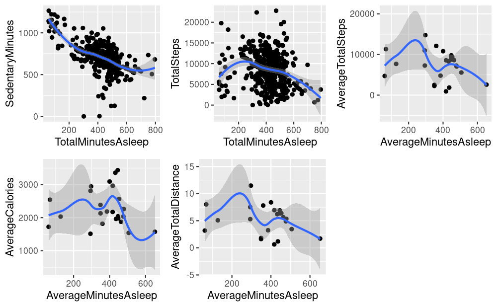

```r
ggarrange(

  combined_data %>%
    ggplot(aes(x = TotalMinutesAsleep, y = SedentaryMinutes)) +
    geom_point() +
    geom_smooth(),

  combined_data %>%
    ggplot(aes(x = TotalMinutesAsleep, y = TotalSteps)) +
    geom_point() +
    geom_smooth(),


  average_combined_data %>%
    ggplot(aes(x = AverageMinutesAsleep, y = AverageTotalSteps)) +
    geom_point() +
    geom_smooth(),

  average_combined_data %>%
    ggplot(aes(x = AverageMinutesAsleep, y = AverageCalories)) +
    geom_point() +
    geom_smooth(),

  average_combined_data %>%
    ggplot(aes(x = AverageMinutesAsleep, y = AverageTotalDistance)) +
    geom_point() +
    geom_smooth()

)
install.packages("ggpubr")
```

It seems like there is no correlation between sleeping minutes and steps/activity. But it seems like more sleep reduces sedentary minutes.

## Conclusions

Bellabeat must continue collecting data about users, and also collect more useful information, such as type of activity practiced (sport, bodybuilding, cycling, running, etc.), weight throughout the day, work data (sedentary, standing , active, etc.).

We could clearly see that by increasing steps and distance we burn more calories, so we could encourage users to be more active, like walking to places instead of driving. The company should send information about steps to users to encourage them to stay active.

Additionally, improving the amount of sleep should help to not be tired during the day and help avoid big amount of sedentary minutes. One way is to reduce time wasted in bed. Additionally, setting an alarm for a certain bedtime can help. This way we can improve sleep time to at least 7 hours, aiming for 8 hours.